# Risk Factor Analysis

## Outcome Variable

**Outcome Variable:** ever_swasted

## Predictor Variables

**Intervention Variable:** meducyrs

**Adjustment Set:**

unadjusted

## Stratifying Variables

The analysis was stratified on these variable(s):

- agecat
- studyid
- country

## Data Summary

| agecat | studyid | country | meducyrs | ever_swasted | n_cell | n |
| --- | --- | --- | --- | --- | --- | --- |
| 0-24 months | ki0047075b-MAL-ED | BANGLADESH | High | 0 | 74 | 213 |
| 0-24 months | ki0047075b-MAL-ED | BANGLADESH | High | 1 | 4 | 213 |
| 0-24 months | ki0047075b-MAL-ED | BANGLADESH | Low | 0 | 63 | 213 |
| 0-24 months | ki0047075b-MAL-ED | BANGLADESH | Low | 1 | 7 | 213 |
| 0-24 months | ki0047075b-MAL-ED | BANGLADESH | Medium | 0 | 61 | 213 |
| 0-24 months | ki0047075b-MAL-ED | BANGLADESH | Medium | 1 | 4 | 213 |
| 0-24 months | ki0047075b-MAL-ED | BRAZIL | High | 0 | 77 | 232 |
| 0-24 months | ki0047075b-MAL-ED | BRAZIL | High | 1 | 2 | 232 |
| 0-24 months | ki0047075b-MAL-ED | BRAZIL | Low | 0 | 62 | 232 |
| 0-24 months | ki0047075b-MAL-ED | BRAZIL | Low | 1 | 1 | 232 |
| 0-24 months | ki0047075b-MAL-ED | BRAZIL | Medium | 0 | 89 | 232 |
| 0-24 months | ki0047075b-MAL-ED | BRAZIL | Medium | 1 | 1 | 232 |
| 0-24 months | ki0047075b-MAL-ED | INDIA | High | 0 | 58 | 220 |
| 0-24 months | ki0047075b-MAL-ED | INDIA | High | 1 | 5 | 220 |
| 0-24 months | ki0047075b-MAL-ED | INDIA | Low | 0 | 68 | 220 |
| 0-24 months | ki0047075b-MAL-ED | INDIA | Low | 1 | 8 | 220 |
| 0-24 months | ki0047075b-MAL-ED | INDIA | Medium | 0 | 74 | 220 |
| 0-24 months | ki0047075b-MAL-ED | INDIA | Medium | 1 | 7 | 220 |
| 0-24 months | ki0047075b-MAL-ED | NEPAL | High | 0 | 52 | 225 |
| 0-24 months | ki0047075b-MAL-ED | NEPAL | High | 1 | 1 | 225 |
| 0-24 months | ki0047075b-MAL-ED | NEPAL | Low | 0 | 93 | 225 |
| 0-24 months | ki0047075b-MAL-ED | NEPAL | Low | 1 | 3 | 225 |
| 0-24 months | ki0047075b-MAL-ED | NEPAL | Medium | 0 | 73 | 225 |
| 0-24 months | ki0047075b-MAL-ED | NEPAL | Medium | 1 | 3 | 225 |
| 0-24 months | ki0047075b-MAL-ED | PERU | High | 0 | 90 | 301 |
| 0-24 months | ki0047075b-MAL-ED | PERU | High | 1 | 0 | 301 |
| 0-24 months | ki0047075b-MAL-ED | PERU | Low | 0 | 102 | 301 |
| 0-24 months | ki0047075b-MAL-ED | PERU | Low | 1 | 2 | 301 |
| 0-24 months | ki0047075b-MAL-ED | PERU | Medium | 0 | 106 | 301 |
| 0-24 months | ki0047075b-MAL-ED | PERU | Medium | 1 | 1 | 301 |

[output cut: 438 more lines]

The following strata were considered:

- agecat: 0-24 months, studyid: ki0047075b-MAL-ED, country: BANGLADESH
- agecat: 0-24 months, studyid: ki0047075b-MAL-ED, country: BRAZIL
- agecat: 0-24 months, studyid: ki0047075b-MAL-ED, country: INDIA
- agecat: 0-24 months, studyid: ki0047075b-MAL-ED, country: NEPAL
- agecat: 0-24 months, studyid: ki0047075b-MAL-ED, country: PERU
- agecat: 0-24 months, studyid: ki0047075b-MAL-ED, country: SOUTH AFRICA
- agecat: 0-24 months, studyid: ki0047075b-MAL-ED, country: TANZANIA, UNITED REPUBLIC OF
- agecat: 0-24 months, studyid: ki1000108-CMC-V-BCS-2002, country: INDIA
- agecat: 0-24 months, studyid: ki1000108-IRC, country: INDIA
- agecat: 0-24 months, studyid: ki1000109-EE, country: PAKISTAN
- agecat: 0-24 months, studyid: ki1000304b-SAS-CompFeed, country: INDIA
- agecat: 0-24 months, studyid: ki1000304b-SAS-FoodSuppl, country: INDIA
- agecat: 0-24 months, studyid: ki1017093-NIH-Birth, country: BANGLADESH
- agecat: 0-24 months, studyid: ki1017093b-PROVIDE, country: BANGLADESH
- agecat: 0-24 months, studyid: ki1017093c-NIH-Crypto, country: BANGLADESH
- agecat: 0-24 months, studyid: ki1066203-TanzaniaChild2, country: TANZANIA, UNITED REPUBLIC OF
- agecat: 0-24 months, studyid: ki1112895-Guatemala BSC, country: GUATEMALA
- agecat: 0-24 months, studyid: ki1113344-GMS-Nepal, country: NEPAL
- agecat: 0-24 months, studyid: ki1119695-PROBIT, country: BELARUS
- agecat: 0-24 months, studyid: ki1126311-ZVITAMBO, country: ZIMBABWE
- agecat: 0-24 months, studyid: ki1135781-COHORTS, country: GUATEMALA
- agecat: 0-24 months, studyid: ki1135781-COHORTS, country: INDIA
- agecat: 0-24 months, studyid: ki1135781-COHORTS, country: PHILIPPINES
- agecat: 0-24 months, studyid: ki1148112-LCNI-5, country: MALAWI
- agecat: 0-24 months, studyid: kiGH5241-JiVitA-3, country: BANGLADESH
- agecat: 0-24 months, studyid: kiGH5241-JiVitA-4, country: BANGLADESH
- agecat: 0-6 months, studyid: ki0047075b-MAL-ED, country: BANGLADESH
- agecat: 0-6 months, studyid: ki0047075b-MAL-ED, country: BRAZIL
- agecat: 0-6 months, studyid: ki0047075b-MAL-ED, country: INDIA
- agecat: 0-6 months, studyid: ki0047075b-MAL-ED, country: NEPAL
- agecat: 0-6 months, studyid: ki0047075b-MAL-ED, country: PERU
- agecat: 0-6 months, studyid: ki0047075b-MAL-ED, country: SOUTH AFRICA
- agecat: 0-6 months, studyid: ki0047075b-MAL-ED, country: TANZANIA, UNITED REPUBLIC OF
- agecat: 0-6 months, studyid: ki1000108-CMC-V-BCS-2002, country: INDIA
- agecat: 0-6 months, studyid: ki1000108-IRC, country: INDIA
- agecat: 0-6 months, studyid: ki1000109-EE, country: PAKISTAN
- agecat: 0-6 months, studyid: ki1000304b-SAS-CompFeed, country: INDIA
- agecat: 0-6 months, studyid: ki1000304b-SAS-FoodSuppl, country: INDIA
- agecat: 0-6 months, studyid: ki1017093-NIH-Birth, country: BANGLADESH
- agecat: 0-6 months, studyid: ki1017093b-PROVIDE, country: BANGLADESH
- agecat: 0-6 months, studyid: ki1017093c-NIH-Crypto, country: BANGLADESH
- agecat: 0-6 months, studyid: ki1066203-TanzaniaChild2, country: TANZANIA, UNITED REPUBLIC OF
- agecat: 0-6 months, studyid: ki1112895-Guatemala BSC, country: GUATEMALA
- agecat: 0-6 months, studyid: ki1113344-GMS-Nepal, country: NEPAL
- agecat: 0-6 months, studyid: ki1119695-PROBIT, country: BELARUS
- agecat: 0-6 months, studyid: ki1126311-ZVITAMBO, country: ZIMBABWE
- agecat: 0-6 months, studyid: ki1135781-COHORTS, country: GUATEMALA
- agecat: 0-6 months, studyid: ki1135781-COHORTS, country: INDIA
- agecat: 0-6 months, studyid: ki1135781-COHORTS, country: PHILIPPINES
- agecat: 0-6 months, studyid: ki1148112-LCNI-5, country: MALAWI
- agecat: 0-6 months, studyid: kiGH5241-JiVitA-3, country: BANGLADESH
- agecat: 0-6 months, studyid: kiGH5241-JiVitA-4, country: BANGLADESH
- agecat: 6-24 months, studyid: ki0047075b-MAL-ED, country: BANGLADESH
- agecat: 6-24 months, studyid: ki0047075b-MAL-ED, country: BRAZIL
- agecat: 6-24 months, studyid: ki0047075b-MAL-ED, country: INDIA
- agecat: 6-24 months, studyid: ki0047075b-MAL-ED, country: NEPAL
- agecat: 6-24 months, studyid: ki0047075b-MAL-ED, country: PERU
- agecat: 6-24 months, studyid: ki0047075b-MAL-ED, country: SOUTH AFRICA
- agecat: 6-24 months, studyid: ki0047075b-MAL-ED, country: TANZANIA, UNITED REPUBLIC OF
- agecat: 6-24 months, studyid: ki1000108-CMC-V-BCS-2002, country: INDIA
- agecat: 6-24 months, studyid: ki1000108-IRC, country: INDIA
- agecat: 6-24 months, studyid: ki1000109-EE, country: PAKISTAN
- agecat: 6-24 months, studyid: ki1000304b-SAS-CompFeed, country: INDIA
- agecat: 6-24 months, studyid: ki1000304b-SAS-FoodSuppl, country: INDIA
- agecat: 6-24 months, studyid: ki1017093-NIH-Birth, country: BANGLADESH
- agecat: 6-24 months, studyid: ki1017093b-PROVIDE, country: BANGLADESH
- agecat: 6-24 months, studyid: ki1017093c-NIH-Crypto, country: BANGLADESH
- agecat: 6-24 months, studyid: ki1066203-TanzaniaChild2, country: TANZANIA, UNITED REPUBLIC OF
- agecat: 6-24 months, studyid: ki1112895-Guatemala BSC, country: GUATEMALA
- agecat: 6-24 months, studyid: ki1113344-GMS-Nepal, country: NEPAL
- agecat: 6-24 months, studyid: ki1119695-PROBIT, country: BELARUS
- agecat: 6-24 months, studyid: ki1126311-ZVITAMBO, country: ZIMBABWE
- agecat: 6-24 months, studyid: ki1135781-COHORTS, country: GUATEMALA
- agecat: 6-24 months, studyid: ki1135781-COHORTS, country: INDIA
- agecat: 6-24 months, studyid: ki1135781-COHORTS, country: PHILIPPINES
- agecat: 6-24 months, studyid: ki1148112-LCNI-5, country: MALAWI
- agecat: 6-24 months, studyid: kiGH5241-JiVitA-3, country: BANGLADESH
- agecat: 6-24 months, studyid: kiGH5241-JiVitA-4, country: BANGLADESH

### Dropped Strata

Some strata were dropped due to rare outcomes:

- agecat: 0-24 months, studyid: ki0047075b-MAL-ED, country: BANGLADESH
- agecat: 0-24 months, studyid: ki0047075b-MAL-ED, country: BRAZIL
- agecat: 0-24 months, studyid: ki0047075b-MAL-ED, country: NEPAL
- agecat: 0-24 months, studyid: ki0047075b-MAL-ED, country: PERU
- agecat: 0-24 months, studyid: ki0047075b-MAL-ED, country: SOUTH AFRICA
- agecat: 0-24 months, studyid: ki0047075b-MAL-ED, country: TANZANIA, UNITED REPUBLIC OF
- agecat: 0-24 months, studyid: ki1000109-EE, country: PAKISTAN
- agecat: 0-24 months, studyid: ki1000304b-SAS-FoodSuppl, country: INDIA
- agecat: 0-24 months, studyid: ki1112895-Guatemala BSC, country: GUATEMALA
- agecat: 0-24 months, studyid: ki1148112-LCNI-5, country: MALAWI
- agecat: 0-24 months, studyid: kiGH5241-JiVitA-4, country: BANGLADESH
- agecat: 0-6 months, studyid: ki0047075b-MAL-ED, country: BANGLADESH
- agecat: 0-6 months, studyid: ki0047075b-MAL-ED, country: BRAZIL
- agecat: 0-6 months, studyid: ki0047075b-MAL-ED, country: INDIA
- agecat: 0-6 months, studyid: ki0047075b-MAL-ED, country: NEPAL
- agecat: 0-6 months, studyid: ki0047075b-MAL-ED, country: PERU
- agecat: 0-6 months, studyid: ki0047075b-MAL-ED, country: SOUTH AFRICA
- agecat: 0-6 months, studyid: ki0047075b-MAL-ED, country: TANZANIA, UNITED REPUBLIC OF
- agecat: 0-6 months, studyid: ki1000109-EE, country: PAKISTAN
- agecat: 0-6 months, studyid: ki1000304b-SAS-CompFeed, country: INDIA
- agecat: 0-6 months, studyid: ki1000304b-SAS-FoodSuppl, country: INDIA
- agecat: 0-6 months, studyid: ki1066203-TanzaniaChild2, country: TANZANIA, UNITED REPUBLIC OF
- agecat: 0-6 months, studyid: ki1112895-Guatemala BSC, country: GUATEMALA
- agecat: 0-6 months, studyid: ki1148112-LCNI-5, country: MALAWI
- agecat: 0-6 months, studyid: kiGH5241-JiVitA-4, country: BANGLADESH
- agecat: 6-24 months, studyid: ki0047075b-MAL-ED, country: BANGLADESH
- agecat: 6-24 months, studyid: ki0047075b-MAL-ED, country: BRAZIL
- agecat: 6-24 months, studyid: ki0047075b-MAL-ED, country: INDIA
- agecat: 6-24 months, studyid: ki0047075b-MAL-ED, country: NEPAL
- agecat: 6-24 months, studyid: ki0047075b-MAL-ED, country: PERU
- agecat: 6-24 months, studyid: ki0047075b-MAL-ED, country: SOUTH AFRICA
- agecat: 6-24 months, studyid: ki0047075b-MAL-ED, country: TANZANIA, UNITED REPUBLIC OF
- agecat: 6-24 months, studyid: ki1000109-EE, country: PAKISTAN
- agecat: 6-24 months, studyid: ki1000304b-SAS-FoodSuppl, country: INDIA
- agecat: 6-24 months, studyid: ki1017093b-PROVIDE, country: BANGLADESH
- agecat: 6-24 months, studyid: ki1017093c-NIH-Crypto, country: BANGLADESH
- agecat: 6-24 months, studyid: ki1112895-Guatemala BSC, country: GUATEMALA
- agecat: 6-24 months, studyid: ki1119695-PROBIT, country: BELARUS
- agecat: 6-24 months, studyid: ki1135781-COHORTS, country: GUATEMALA
- agecat: 6-24 months, studyid: ki1148112-LCNI-5, country: MALAWI
- agecat: 6-24 months, studyid: kiGH5241-JiVitA-4, country: BANGLADESH

## Methods Detail

We’re interested in the causal parameters $E[Y_a]$ for all values of $a \in \mathcal{A}$. These parameters represent the mean outcome if, possibly contrary to fact, we intervened to set all units to have $A=a$. Under the randomization and positivity assumptions, these are identified by the statistical parameters $\psi_a=E_W[E_{Y|A,W}(Y|A=a,W)]$. In addition, we’re interested in the mean of $Y$, $E[Y]$ under no intervention (the observed mean). We will estimate these parameters by using SuperLearner to fit the relevant likelihood factors – $E_{Y|A,W}(Y|A=a,W)$ and $p(A=a|W)$, and then updating our likelihood fit using a joint TMLE.

For unadjusted analyses ($W=\{\}$), initial likelihoods were estimated using Lrnr_glm to estimate the simple $E(Y|A)$ and Lrnr_mean to estimate $p(A)$. For adjusted analyses, a small library containing Lrnr_glmnet, Lrnr_xgboost, and Lrnr_mean was used.

Having estimated these parameters, we will then use the delta method to estimate relative risks and attributable risks relative to a prespecified baseline level of $A$.

# Results Detail

## Results Plots

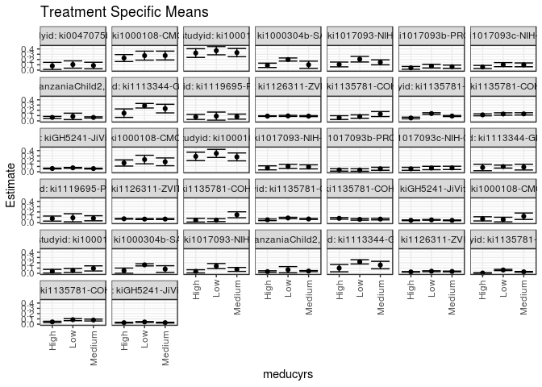

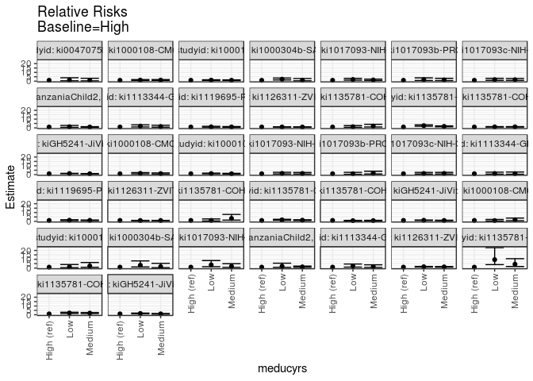

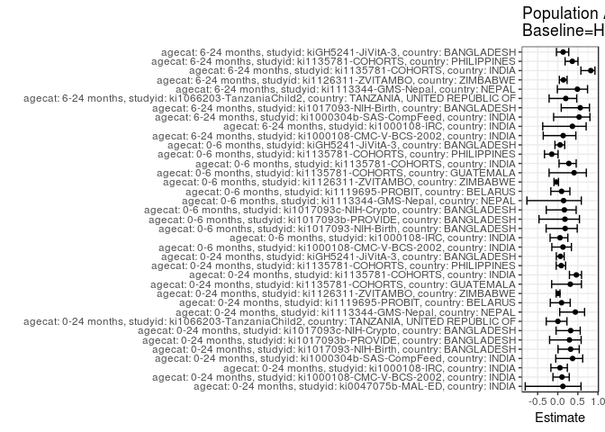

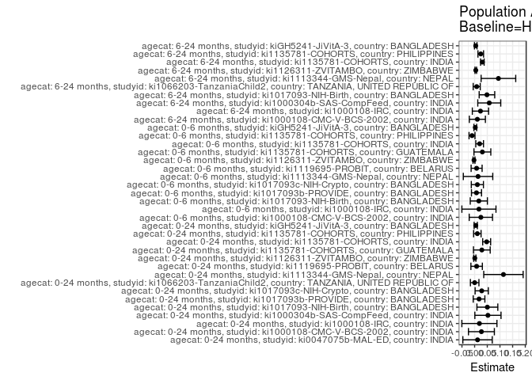

## Results Table

### Parameter: TSM

| agecat | studyid | country | intervention_level | baseline_level | estimate | ci_lower | ci_upper |
| --- | --- | --- | --- | --- | --- | --- | --- |
| 0-24 months | ki0047075b-MAL-ED | INDIA | High | NA | 0.0793651 | 0.0124652 | 0.1462650 |
| 0-24 months | ki0047075b-MAL-ED | INDIA | Low | NA | 0.1052632 | 0.0361093 | 0.1744170 |
| 0-24 months | ki0047075b-MAL-ED | INDIA | Medium | NA | 0.0864198 | 0.0250895 | 0.1477500 |
| 0-24 months | ki1000108-CMC-V-BCS-2002 | INDIA | High | NA | 0.2278481 | 0.1623579 | 0.2933383 |
| 0-24 months | ki1000108-CMC-V-BCS-2002 | INDIA | Low | NA | 0.2735849 | 0.1886049 | 0.3585649 |
| 0-24 months | ki1000108-CMC-V-BCS-2002 | INDIA | Medium | NA | 0.2752294 | 0.1912707 | 0.3591880 |
| 0-24 months | ki1000108-IRC | INDIA | High | NA | 0.3225806 | 0.2402018 | 0.4049594 |
| 0-24 months | ki1000108-IRC | INDIA | Low | NA | 0.3673469 | 0.2893207 | 0.4453732 |
| 0-24 months | ki1000108-IRC | INDIA | Medium | NA | 0.3309353 | 0.2526146 | 0.4092560 |
| 0-24 months | ki1000304b-SAS-CompFeed | INDIA | High | NA | 0.0900000 | 0.0487544 | 0.1312457 |
| 0-24 months | ki1000304b-SAS-CompFeed | INDIA | Low | NA | 0.2000000 | 0.1708202 | 0.2291798 |
| 0-24 months | ki1000304b-SAS-CompFeed | INDIA | Medium | NA | 0.1012658 | 0.0331527 | 0.1693790 |
| 0-24 months | ki1017093-NIH-Birth | BANGLADESH | High | NA | 0.1067416 | 0.0613431 | 0.1521401 |
| 0-24 months | ki1017093-NIH-Birth | BANGLADESH | Low | NA | 0.2061404 | 0.1535892 | 0.2586915 |
| 0-24 months | ki1017093-NIH-Birth | BANGLADESH | Medium | NA | 0.1467890 | 0.0997733 | 0.1938047 |
| 0-24 months | ki1017093b-PROVIDE | BANGLADESH | High | NA | 0.0425532 | 0.0167277 | 0.0683786 |
| 0-24 months | ki1017093b-PROVIDE | BANGLADESH | Low | NA | 0.0747664 | 0.0395024 | 0.1100303 |
| 0-24 months | ki1017093b-PROVIDE | BANGLADESH | Medium | NA | 0.0637450 | 0.0335008 | 0.0939892 |
| 0-24 months | ki1017093c-NIH-Crypto | BANGLADESH | High | NA | 0.0590551 | 0.0300464 | 0.0880639 |
| 0-24 months | ki1017093c-NIH-Crypto | BANGLADESH | Low | NA | 0.1033058 | 0.0649340 | 0.1416775 |
| 0-24 months | ki1017093c-NIH-Crypto | BANGLADESH | Medium | NA | 0.0992366 | 0.0630102 | 0.1354631 |
| 0-24 months | ki1066203-TanzaniaChild2 | TANZANIA, UNITED REPUBLIC OF | High | NA | 0.0660225 | 0.0464878 | 0.0855573 |
| 0-24 months | ki1066203-TanzaniaChild2 | TANZANIA, UNITED REPUBLIC OF | Low | NA | 0.0853659 | 0.0248738 | 0.1458579 |
| 0-24 months | ki1066203-TanzaniaChild2 | TANZANIA, UNITED REPUBLIC OF | Medium | NA | 0.0653595 | 0.0535488 | 0.0771701 |
| 0-24 months | ki1113344-GMS-Nepal | NEPAL | High | NA | 0.1466667 | 0.0665348 | 0.2267985 |
| 0-24 months | ki1113344-GMS-Nepal | NEPAL | Low | NA | 0.2874109 | 0.2441455 | 0.3306764 |
| 0-24 months | ki1113344-GMS-Nepal | NEPAL | Medium | NA | 0.2330097 | 0.1512999 | 0.3147195 |
| 0-24 months | ki1119695-PROBIT | BELARUS | High | NA | 0.0758405 | 0.0275017 | 0.1241793 |
| 0-24 months | ki1119695-PROBIT | BELARUS | Low | NA | 0.0909091 | 0.0144577 | 0.1673604 |
| 0-24 months | ki1119695-PROBIT | BELARUS | Medium | NA | 0.0815534 | 0.0337164 | 0.1293904 |

[output cut: 81 more lines]

### Parameter: E(Y)

| agecat | studyid | country | intervention_level | baseline_level | estimate | ci_lower | ci_upper |
| --- | --- | --- | --- | --- | --- | --- | --- |
| 0-24 months | ki0047075b-MAL-ED | INDIA | NA | NA | 0.0909091 | 0.0528347 | 0.1289835 |
| 0-24 months | ki1000108-CMC-V-BCS-2002 | INDIA | NA | NA | 0.2546917 | 0.2104174 | 0.2989660 |
| 0-24 months | ki1000108-IRC | INDIA | NA | NA | 0.3414634 | 0.2955068 | 0.3874201 |
| 0-24 months | ki1000304b-SAS-CompFeed | INDIA | NA | NA | 0.1425486 | 0.1120439 | 0.1730533 |
| 0-24 months | ki1017093-NIH-Birth | BANGLADESH | NA | NA | 0.1570513 | 0.1284803 | 0.1856223 |
| 0-24 months | ki1017093b-PROVIDE | BANGLADESH | NA | NA | 0.0600000 | 0.0423945 | 0.0776055 |
| 0-24 months | ki1017093c-NIH-Crypto | BANGLADESH | NA | NA | 0.0870712 | 0.0669870 | 0.1071555 |
| 0-24 months | ki1066203-TanzaniaChild2 | TANZANIA, UNITED REPUBLIC OF | NA | NA | 0.0662196 | 0.0562399 | 0.0761994 |
| 0-24 months | ki1113344-GMS-Nepal | NEPAL | NA | NA | 0.2604341 | 0.2252590 | 0.2956091 |
| 0-24 months | ki1119695-PROBIT | BELARUS | NA | NA | 0.0837948 | 0.0281977 | 0.1393918 |
| 0-24 months | ki1126311-ZVITAMBO | ZIMBABWE | NA | NA | 0.0916014 | 0.0868091 | 0.0963938 |
| 0-24 months | ki1135781-COHORTS | GUATEMALA | NA | NA | 0.0913313 | 0.0690992 | 0.1135634 |
| 0-24 months | ki1135781-COHORTS | INDIA | NA | NA | 0.1030116 | 0.0952175 | 0.1108057 |
| 0-24 months | ki1135781-COHORTS | PHILIPPINES | NA | NA | 0.1254516 | 0.1136848 | 0.1372183 |
| 0-24 months | kiGH5241-JiVitA-3 | BANGLADESH | NA | NA | 0.0650736 | 0.0602289 | 0.0699183 |
| 0-6 months | ki1000108-CMC-V-BCS-2002 | INDIA | NA | NA | 0.1902174 | 0.1500638 | 0.2303710 |
| 0-6 months | ki1000108-IRC | INDIA | NA | NA | 0.3073171 | 0.2626027 | 0.3520314 |
| 0-6 months | ki1017093-NIH-Birth | BANGLADESH | NA | NA | 0.0900322 | 0.0675202 | 0.1125442 |
| 0-6 months | ki1017093b-PROVIDE | BANGLADESH | NA | NA | 0.0414286 | 0.0266555 | 0.0562017 |
| 0-6 months | ki1017093c-NIH-Crypto | BANGLADESH | NA | NA | 0.0659631 | 0.0482810 | 0.0836451 |
| 0-6 months | ki1113344-GMS-Nepal | NEPAL | NA | NA | 0.0934891 | 0.0701565 | 0.1168218 |
| 0-6 months | ki1119695-PROBIT | BELARUS | NA | NA | 0.0829436 | 0.0271087 | 0.1387786 |
| 0-6 months | ki1126311-ZVITAMBO | ZIMBABWE | NA | NA | 0.0687062 | 0.0644898 | 0.0729225 |
| 0-6 months | ki1135781-COHORTS | GUATEMALA | NA | NA | 0.0753968 | 0.0523231 | 0.0984706 |
| 0-6 months | ki1135781-COHORTS | INDIA | NA | NA | 0.0718095 | 0.0650627 | 0.0785562 |
| 0-6 months | ki1135781-COHORTS | PHILIPPINES | NA | NA | 0.0693167 | 0.0602923 | 0.0783411 |
| 0-6 months | kiGH5241-JiVitA-3 | BANGLADESH | NA | NA | 0.0450260 | 0.0408089 | 0.0492432 |
| 6-24 months | ki1000108-CMC-V-BCS-2002 | INDIA | NA | NA | 0.0804290 | 0.0527929 | 0.1080650 |
| 6-24 months | ki1000108-IRC | INDIA | NA | NA | 0.0634146 | 0.0397960 | 0.0870333 |
| 6-24 months | ki1000304b-SAS-CompFeed | INDIA | NA | NA | 0.1087963 | 0.0724447 | 0.1451479 |
| 6-24 months | ki1017093-NIH-Birth | BANGLADESH | NA | NA | 0.0868762 | 0.0631205 | 0.1106318 |
| 6-24 months | ki1066203-TanzaniaChild2 | TANZANIA, UNITED REPUBLIC OF | NA | NA | 0.0412730 | 0.0325768 | 0.0499692 |
| 6-24 months | ki1113344-GMS-Nepal | NEPAL | NA | NA | 0.1925043 | 0.1605823 | 0.2244262 |
| 6-24 months | ki1126311-ZVITAMBO | ZIMBABWE | NA | NA | 0.0325873 | 0.0292196 | 0.0359550 |
| 6-24 months | ki1135781-COHORTS | INDIA | NA | NA | 0.0372331 | 0.0322193 | 0.0422468 |
| 6-24 months | ki1135781-COHORTS | PHILIPPINES | NA | NA | 0.0669277 | 0.0576848 | 0.0761707 |
| 6-24 months | kiGH5241-JiVitA-3 | BANGLADESH | NA | NA | 0.0327715 | 0.0284953 | 0.0370478 |

### Parameter: RR

| agecat | studyid | country | intervention_level | baseline_level | estimate | ci_lower | ci_upper |
| --- | --- | --- | --- | --- | --- | --- | --- |
| 0-24 months | ki0047075b-MAL-ED | INDIA | High | High | 1.0000000 | 1.0000000 | 1.000000 |
| 0-24 months | ki0047075b-MAL-ED | INDIA | Low | High | 1.3263158 | 0.4555241 | 3.861735 |
| 0-24 months | ki0047075b-MAL-ED | INDIA | Medium | High | 1.0888889 | 0.3617706 | 3.277433 |
| 0-24 months | ki1000108-CMC-V-BCS-2002 | INDIA | High | High | 1.0000000 | 1.0000000 | 1.000000 |
| 0-24 months | ki1000108-CMC-V-BCS-2002 | INDIA | Low | High | 1.2007338 | 0.7864177 | 1.833328 |
| 0-24 months | ki1000108-CMC-V-BCS-2002 | INDIA | Medium | High | 1.2079511 | 0.7943702 | 1.836859 |
| 0-24 months | ki1000108-IRC | INDIA | High | High | 1.0000000 | 1.0000000 | 1.000000 |
| 0-24 months | ki1000108-IRC | INDIA | Low | High | 1.1387755 | 0.8169244 | 1.587429 |
| 0-24 months | ki1000108-IRC | INDIA | Medium | High | 1.0258993 | 0.7242592 | 1.453167 |
| 0-24 months | ki1000304b-SAS-CompFeed | INDIA | High | High | 1.0000000 | 1.0000000 | 1.000000 |
| 0-24 months | ki1000304b-SAS-CompFeed | INDIA | Low | High | 2.2222220 | 1.3923014 | 3.546840 |
| 0-24 months | ki1000304b-SAS-CompFeed | INDIA | Medium | High | 1.1251757 | 0.4267806 | 2.966443 |
| 0-24 months | ki1017093-NIH-Birth | BANGLADESH | High | High | 1.0000000 | 1.0000000 | 1.000000 |
| 0-24 months | ki1017093-NIH-Birth | BANGLADESH | Low | High | 1.9312096 | 1.1761944 | 3.170879 |
| 0-24 months | ki1017093-NIH-Birth | BANGLADESH | Medium | High | 1.3751811 | 0.8074757 | 2.342019 |
| 0-24 months | ki1017093b-PROVIDE | BANGLADESH | High | High | 1.0000000 | 1.0000000 | 1.000000 |
| 0-24 months | ki1017093b-PROVIDE | BANGLADESH | Low | High | 1.7570092 | 0.8146380 | 3.789513 |
| 0-24 months | ki1017093b-PROVIDE | BANGLADESH | Medium | High | 1.4980079 | 0.6933570 | 3.236468 |
| 0-24 months | ki1017093c-NIH-Crypto | BANGLADESH | High | High | 1.0000000 | 1.0000000 | 1.000000 |
| 0-24 months | ki1017093c-NIH-Crypto | BANGLADESH | Low | High | 1.7493113 | 0.9449556 | 3.238343 |
| 0-24 months | ki1017093c-NIH-Crypto | BANGLADESH | Medium | High | 1.6804071 | 0.9112190 | 3.098891 |
| 0-24 months | ki1066203-TanzaniaChild2 | TANZANIA, UNITED REPUBLIC OF | High | High | 1.0000000 | 1.0000000 | 1.000000 |
| 0-24 months | ki1066203-TanzaniaChild2 | TANZANIA, UNITED REPUBLIC OF | Low | High | 1.2929804 | 0.5999184 | 2.786709 |
| 0-24 months | ki1066203-TanzaniaChild2 | TANZANIA, UNITED REPUBLIC OF | Medium | High | 0.9899570 | 0.6999193 | 1.400183 |
| 0-24 months | ki1113344-GMS-Nepal | NEPAL | High | High | 1.0000000 | 1.0000000 | 1.000000 |
| 0-24 months | ki1113344-GMS-Nepal | NEPAL | Low | High | 1.9596200 | 1.1118640 | 3.453759 |
| 0-24 months | ki1113344-GMS-Nepal | NEPAL | Medium | High | 1.5887026 | 0.8300315 | 3.040819 |
| 0-24 months | ki1119695-PROBIT | BELARUS | High | High | 1.0000000 | 1.0000000 | 1.000000 |
| 0-24 months | ki1119695-PROBIT | BELARUS | Low | High | 1.1986879 | 0.7930359 | 1.811838 |
| 0-24 months | ki1119695-PROBIT | BELARUS | Medium | High | 1.0753278 | 0.7598733 | 1.521740 |

[output cut: 81 more lines]

### Parameter: PAR

| agecat | studyid | country | intervention_level | baseline_level | estimate | ci_lower | ci_upper |
| --- | --- | --- | --- | --- | --- | --- | --- |
| 0-24 months | ki0047075b-MAL-ED | INDIA | High | NA | 0.0115440 | -0.0464384 | 0.0695264 |
| 0-24 months | ki1000108-CMC-V-BCS-2002 | INDIA | High | NA | 0.0268436 | -0.0242997 | 0.0779869 |
| 0-24 months | ki1000108-IRC | INDIA | High | NA | 0.0188828 | -0.0503517 | 0.0881173 |
| 0-24 months | ki1000304b-SAS-CompFeed | INDIA | High | NA | 0.0525486 | 0.0009140 | 0.1041831 |
| 0-24 months | ki1017093-NIH-Birth | BANGLADESH | High | NA | 0.0503097 | 0.0090606 | 0.0915588 |
| 0-24 months | ki1017093b-PROVIDE | BANGLADESH | High | NA | 0.0174468 | -0.0055553 | 0.0404489 |
| 0-24 months | ki1017093c-NIH-Crypto | BANGLADESH | High | NA | 0.0280161 | 0.0019217 | 0.0541106 |
| 0-24 months | ki1066203-TanzaniaChild2 | TANZANIA, UNITED REPUBLIC OF | High | NA | 0.0001971 | -0.0166125 | 0.0170066 |
| 0-24 months | ki1113344-GMS-Nepal | NEPAL | High | NA | 0.1137674 | 0.0359828 | 0.1915520 |
| 0-24 months | ki1119695-PROBIT | BELARUS | High | NA | 0.0079543 | -0.0146844 | 0.0305930 |
| 0-24 months | ki1126311-ZVITAMBO | ZIMBABWE | High | NA | 0.0007525 | -0.0036515 | 0.0051565 |
| 0-24 months | ki1135781-COHORTS | GUATEMALA | High | NA | 0.0284741 | -0.0045057 | 0.0614540 |
| 0-24 months | ki1135781-COHORTS | INDIA | High | NA | 0.0475261 | 0.0318497 | 0.0632026 |
| 0-24 months | ki1135781-COHORTS | PHILIPPINES | High | NA | 0.0107255 | -0.0039802 | 0.0254313 |
| 0-24 months | kiGH5241-JiVitA-3 | BANGLADESH | High | NA | 0.0043458 | -0.0020226 | 0.0107142 |
| 0-6 months | ki1000108-CMC-V-BCS-2002 | INDIA | High | NA | 0.0246123 | -0.0213201 | 0.0705447 |
| 0-6 months | ki1000108-IRC | INDIA | High | NA | 0.0169945 | -0.0502926 | 0.0842816 |
| 0-6 months | ki1017093-NIH-Birth | BANGLADESH | High | NA | 0.0165858 | -0.0172399 | 0.0504116 |
| 0-6 months | ki1017093b-PROVIDE | BANGLADESH | High | NA | 0.0073860 | -0.0124915 | 0.0272636 |
| 0-6 months | ki1017093c-NIH-Crypto | BANGLADESH | High | NA | 0.0108450 | -0.0130878 | 0.0347777 |
| 0-6 months | ki1113344-GMS-Nepal | NEPAL | High | NA | 0.0134891 | -0.0446046 | 0.0715829 |
| 0-6 months | ki1119695-PROBIT | BELARUS | High | NA | 0.0078850 | -0.0138113 | 0.0295813 |
| 0-6 months | ki1126311-ZVITAMBO | ZIMBABWE | High | NA | -0.0024749 | -0.0063344 | 0.0013847 |
| 0-6 months | ki1135781-COHORTS | GUATEMALA | High | NA | 0.0306207 | -0.0026612 | 0.0639027 |
| 0-6 months | ki1135781-COHORTS | INDIA | High | NA | 0.0198095 | 0.0046198 | 0.0349991 |
| 0-6 months | ki1135781-COHORTS | PHILIPPINES | High | NA | -0.0103066 | -0.0220334 | 0.0014202 |
| 0-6 months | kiGH5241-JiVitA-3 | BANGLADESH | High | NA | 0.0026493 | -0.0028155 | 0.0081142 |
| 6-24 months | ki1000108-CMC-V-BCS-2002 | INDIA | High | NA | 0.0108087 | -0.0208939 | 0.0425113 |
| 6-24 months | ki1000108-IRC | INDIA | High | NA | 0.0230920 | -0.0090432 | 0.0552273 |
| 6-24 months | ki1000304b-SAS-CompFeed | INDIA | High | NA | 0.0577759 | 0.0124483 | 0.1031035 |
| 6-24 months | ki1017093-NIH-Birth | BANGLADESH | High | NA | 0.0486596 | 0.0179613 | 0.0793579 |
| 6-24 months | ki1066203-TanzaniaChild2 | TANZANIA, UNITED REPUBLIC OF | High | NA | 0.0081991 | -0.0056758 | 0.0220739 |
| 6-24 months | ki1113344-GMS-Nepal | NEPAL | High | NA | 0.0939127 | 0.0255722 | 0.1622532 |
| 6-24 months | ki1126311-ZVITAMBO | ZIMBABWE | High | NA | 0.0045922 | 0.0014393 | 0.0077450 |
| 6-24 months | ki1135781-COHORTS | INDIA | High | NA | 0.0305664 | 0.0235113 | 0.0376215 |
| 6-24 months | ki1135781-COHORTS | PHILIPPINES | High | NA | 0.0242332 | 0.0131599 | 0.0353066 |
| 6-24 months | kiGH5241-JiVitA-3 | BANGLADESH | High | NA | 0.0043680 | -0.0006750 | 0.0094110 |

### Parameter: PAF

| agecat | studyid | country | intervention_level | baseline_level | estimate | ci_lower | ci_upper |
| --- | --- | --- | --- | --- | --- | --- | --- |
| 0-24 months | ki0047075b-MAL-ED | INDIA | High | NA | 0.1269841 | -0.8088255 | 0.5786455 |
| 0-24 months | ki1000108-CMC-V-BCS-2002 | INDIA | High | NA | 0.1053964 | -0.1193233 | 0.2850005 |
| 0-24 months | ki1000108-IRC | INDIA | High | NA | 0.0552995 | -0.1708578 | 0.2377734 |
| 0-24 months | ki1000304b-SAS-CompFeed | INDIA | High | NA | 0.3686363 | -0.0497531 | 0.6202725 |
| 0-24 months | ki1017093-NIH-Birth | BANGLADESH | High | NA | 0.3203394 | 0.0068692 | 0.5348663 |
| 0-24 months | ki1017093b-PROVIDE | BANGLADESH | High | NA | 0.2907801 | -0.2027902 | 0.5818117 |
| 0-24 months | ki1017093c-NIH-Crypto | BANGLADESH | High | NA | 0.3217609 | -0.0425310 | 0.5587582 |
| 0-24 months | ki1066203-TanzaniaChild2 | TANZANIA, UNITED REPUBLIC OF | High | NA | 0.0029760 | -0.2861107 | 0.2270830 |
| 0-24 months | ki1113344-GMS-Nepal | NEPAL | High | NA | 0.4368376 | 0.0488833 | 0.6665479 |
| 0-24 months | ki1119695-PROBIT | BELARUS | High | NA | 0.0949255 | -0.1859196 | 0.3092619 |
| 0-24 months | ki1126311-ZVITAMBO | ZIMBABWE | High | NA | 0.0082151 | -0.0410454 | 0.0551447 |
| 0-24 months | ki1135781-COHORTS | GUATEMALA | High | NA | 0.3117676 | -0.1513898 | 0.5886155 |
| 0-24 months | ki1135781-COHORTS | INDIA | High | NA | 0.4613667 | 0.2902040 | 0.5912546 |
| 0-24 months | ki1135781-COHORTS | PHILIPPINES | High | NA | 0.0854954 | -0.0393412 | 0.1953378 |
| 0-24 months | kiGH5241-JiVitA-3 | BANGLADESH | High | NA | 0.0667828 | -0.0362624 | 0.1595812 |
| 0-6 months | ki1000108-CMC-V-BCS-2002 | INDIA | High | NA | 0.1293904 | -0.1476872 | 0.3395751 |
| 0-6 months | ki1000108-IRC | INDIA | High | NA | 0.0552995 | -0.1910723 | 0.2507097 |
| 0-6 months | ki1017093-NIH-Birth | BANGLADESH | High | NA | 0.1842211 | -0.2892066 | 0.4837948 |
| 0-6 months | ki1017093b-PROVIDE | BANGLADESH | High | NA | 0.1782832 | -0.4663291 | 0.5395178 |
| 0-6 months | ki1017093c-NIH-Crypto | BANGLADESH | High | NA | 0.1644094 | -0.2862845 | 0.4571873 |
| 0-6 months | ki1113344-GMS-Nepal | NEPAL | High | NA | 0.1442857 | -0.7671143 | 0.5856256 |
| 0-6 months | ki1119695-PROBIT | BELARUS | High | NA | 0.0950645 | -0.1723030 | 0.3014535 |
| 0-6 months | ki1126311-ZVITAMBO | ZIMBABWE | High | NA | -0.0360210 | -0.0937073 | 0.0186227 |
| 0-6 months | ki1135781-COHORTS | GUATEMALA | High | NA | 0.4061272 | -0.2154366 | 0.7098287 |
| 0-6 months | ki1135781-COHORTS | INDIA | High | NA | 0.2758614 | 0.0320920 | 0.4582370 |
| 0-6 months | ki1135781-COHORTS | PHILIPPINES | High | NA | -0.1486886 | -0.3298919 | 0.0078250 |
| 0-6 months | kiGH5241-JiVitA-3 | BANGLADESH | High | NA | 0.0588402 | -0.0702781 | 0.1723816 |
| 6-24 months | ki1000108-CMC-V-BCS-2002 | INDIA | High | NA | 0.1343882 | -0.3612271 | 0.4495527 |
| 6-24 months | ki1000108-IRC | INDIA | High | NA | 0.3641439 | -0.3738866 | 0.7057159 |
| 6-24 months | ki1000304b-SAS-CompFeed | INDIA | High | NA | 0.5310465 | -0.1026097 | 0.8005483 |
| 6-24 months | ki1017093-NIH-Birth | BANGLADESH | High | NA | 0.5601030 | 0.0863807 | 0.7881947 |
| 6-24 months | ki1066203-TanzaniaChild2 | TANZANIA, UNITED REPUBLIC OF | High | NA | 0.1986545 | -0.2153224 | 0.4716180 |
| 6-24 months | ki1113344-GMS-Nepal | NEPAL | High | NA | 0.4878474 | -0.0103504 | 0.7403868 |
| 6-24 months | ki1126311-ZVITAMBO | ZIMBABWE | High | NA | 0.1409195 | 0.0396713 | 0.2314930 |
| 6-24 months | ki1135781-COHORTS | INDIA | High | NA | 0.8209477 | 0.5757823 | 0.9244262 |
| 6-24 months | ki1135781-COHORTS | PHILIPPINES | High | NA | 0.3620806 | 0.1822304 | 0.5023767 |
| 6-24 months | kiGH5241-JiVitA-3 | BANGLADESH | High | NA | 0.1332867 | -0.0332062 | 0.2729506 |